# Les Contes d’Hoffmann

### Zweiter Akt

Mit Spannung erwartet man die Präsentation der neuesten Erfindung des Physikers Spalanzani: die Puppe Olympia. Noch bevor sie dem neugierigen Publikum vorgestellt wird, gelingt es Hoffmann, einen Blick auf sie zu werfen – und er ist sofort hingerissen. Als ihm Coppélius, der sich als Freund Spalanzanis ausgibt und mit optischen Geräten handelt, eine Wunderbrille verkauft, ist Hoffmanns Schicksal besiegelt: Er verliebt sich in Olympia und glaubt in jedem ihrer mechanischen Worte eine heiße Liebesbekundung zu hören. Beim gemeinsamen Walzer gerät die Puppe außer Kontrolle, Hoffmann verliert seine Brille – und mit ihr die Illusion. Die bittere, schamvolle Erkenntnis trifft ihn hart: Er hat sich in einen Automaten verliebt.

### Dritter Akt

inständig, auf ihre geliebte Musik zu verzichten – und sie willigt widerstrebend ein. Doch kaum ist Hoffmann fort, erscheint Miracle erneut. Mit glühenden Worten malt er ihr ein Leben als bejubelte Sängerin aus. Antonia ringt mit sich, doch als das Bild ihrer verstorbenen Mutter vor ihr erscheint, kann sie nicht widerstehen. Sie beginnt zu singen – und stirbt.

### Vierter Akt

Von Antonias Tod gezeichnet, schwört Hoffmann der romantischen Liebe ab. Nur noch dem Vergnügen will er sich hingeben – und der schönen Kurtisane Giulietta. Sie allein scheint noch an sein Herz zu rühren. Doch Giulietta steht unter dem Einfluss des zwielichtigen Dapertutto, der sie beauftragt, Hoffmann zu verführen und ihm sein Spiegelbild zu rauben. Zunächst zögert sie, doch Dapertutto versteht es, ihre Schwächen zu nutzen – sie gibt nach. Als Hoffmann erkennt, dass auch Giulietta ihn betrogen hat, packt ihn die Wut. Von Dapertutto angestachelt, tötet er sie – und begreift im letzten Moment: Der Dämon, der ihn lenkt, ist kein anderer als der Teufel selbst, der ihm sein Leben lang gefolgt ist.

### Fünfter Akt (Epilog)

Hoffmann hat auserzählt, die Karten liegen auf dem Tisch. Unter den Augen aller Begegnungen seines Lebens fällt die Entscheidung über sein Los: Apotheose oder Höllenfahrt?

> „Was für ein großartiger Opernabend!"

> rbb 24 Inforadio, 17. November 2025

> „Jacques Offenbachs *Les Contes d’Hoffmann* an der Staatsoper hat alles, was man sich von einer abendfüllenden, fantastischen Oper wünscht."

> Berliner Morgenpost, 18. November 2025

> „Die Staatskapelle Berlin unter dem Dirigat von Bertrand de Billy – feinfühlig, nie zu dick auftragend, dabei jeden Dreh, jeden Spin der Inszenierung mitmachend.“

> rbb 24 Inforadio, 17. November 2025

> „Star-Tenor Pene Pati triumphiert an Staatsoper"

> B.Z., 17. November 2025

> „Ein großes Zaubertheater-Spektakel. Und auch die Sängerbesetzung ist fantastisch.“

> Tagesspiegel, 17. November 2025

[Programmbuch Download](https://www.staatsoper-berlin.de/downloads-b/de/produktion/21881/programmbuch/e69e4e97a097c1a59aa26d8044dfae26/OB_202425_premiere_lescontes_digital.pdf)

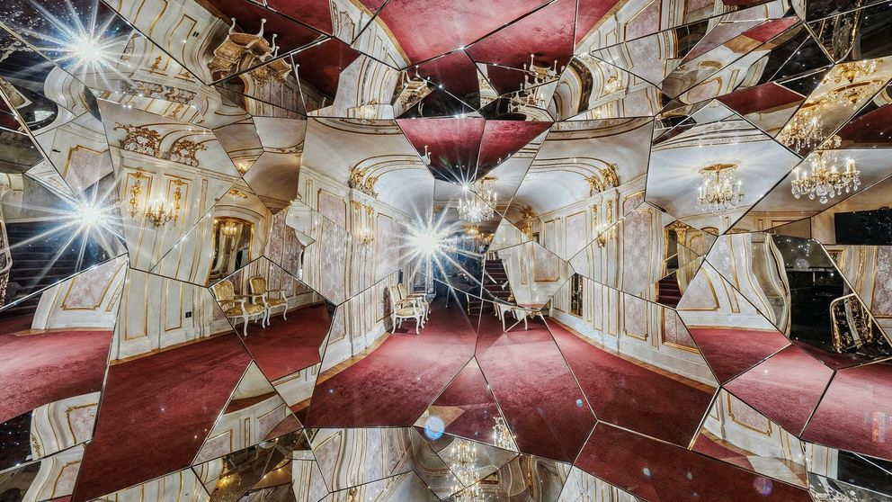

### [Zwischen Surrealismus und Romantik](https://www.staatsoper-berlin.de/de/magazin/hoffmann/)

[figure not shown]

[interactive chart not shown]